# G1401211002 DIVA NISFU MUSTIKA

# Packages

```r
library(ggplot2)
library(tsibble)
library(tseries)
library(MASS)
library(forecast)
library(TSA)
library(TTR)
library(aTSA)
library(graphics)
library(readxl)
library(rio)
library(imputeTS)
```

# Data

```r
data <- import("https://raw.githubusercontent.com/divanm/mpdw/main/Data/DATA%20IDX%20COMPOSITE%20JKSE.csv")
head(data)
```

```
##         Date     Open     High      Low    Close Adj Close    Volume
## 1 2020-04-06 4623.429 4975.536 4562.902 4649.079  4649.079 255758500
## 2 2020-04-13 4649.079 4747.725 4480.607 4634.821  4634.821 218419900
## 3 2020-04-20 4634.821 4669.542 4441.090 4496.064  4496.064 238397200
## 4 2020-04-27 4496.064 4726.774 4474.893 4716.403  4716.403 183906700
## 5 2020-05-04 4716.403 4716.403 4576.228 4597.430  4597.430 179791700
## 6 2020-05-11 4597.430 4659.862 4460.273 4507.607  4507.607 231060000
```

```r
dim(data)
```

```
## [1] 143   7
```

# Mengambil data close

```r
data <- as.numeric(data$Close)
data <- as.data.frame(data)
```

# Mengecek keberadaan missing value

```r
data[which(is.na(data$data)),]
```

```
## [1] NA
```

# Menduga missing value

```r
data <- na_interpolation(data, option = "spline")
data[109,]
```

```
## [1] 6840.217
```

# Mengubah data menjadi data time series

```r
data.ts <- ts(data)
```

# Eksplorasi Data

## Plot Data Penuh

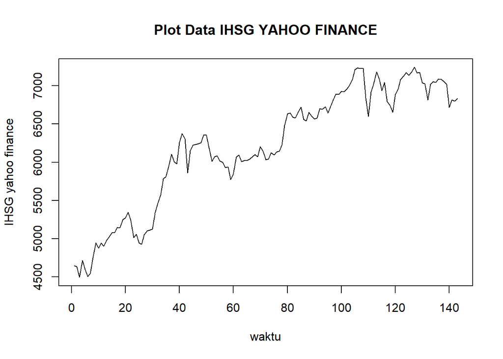

```r
plot.ts(data.ts, lty=1, xlab="waktu", ylab="IHSG yahoo finance", main="Plot Data IHSG YAHOO FINANCE")
```

Berdasarkan plot data deret waktu, terlihat bahwa data cenderung memiliki trend yang naik. Berdasarkan pola data, pembagian data latih dan data uji ditetapkan dengan proporsi 80%:20%.

## Pembagian Data

Data kemudian dibagi menjadi data latih dan data uji. Pembagian kali ini dilakukan dengan proporsi / perbandingan, yaitu 80:20.

```r
data.train <- data$data[1:115]
train.ts <- ts(data.train)
data.test <- data$data[116:143]
test.ts <- ts(data.test)
```

## Plot Data Latih

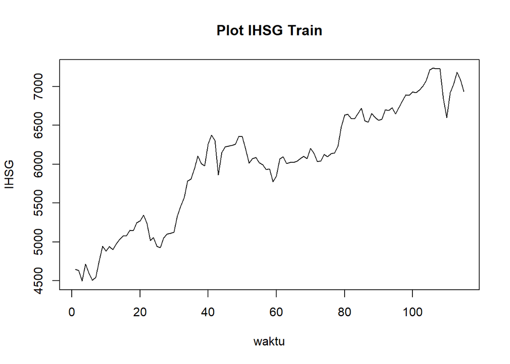

```r
train.ts<-ts(data.train)
plot.ts(train.ts, lty=1, xlab="waktu", ylab="IHSG", main="Plot IHSG Train")
```

Berdasarkan plot data deret waktu pada data latih, terlihat bahwa data cenderung memiliki trend yang naik dan cenderung tidak bergerak pada nilai tengah tertentu. Hal ini mengindikasikan bahwa data tidak stasioner dalam rataan.

## Plot Data Uji

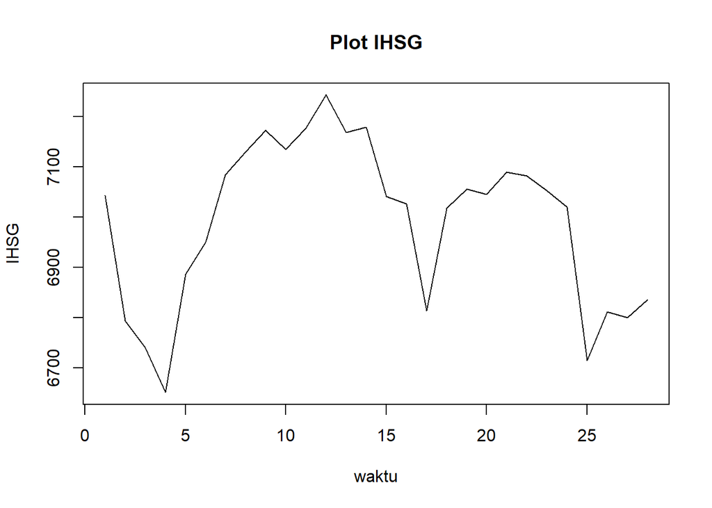

```r
test.ts<-ts(data.test)
plot.ts(test.ts, lty=1, xlab="waktu", ylab="IHSG", main="Plot IHSG")
```

# Uji Stasioneritas Data

## Plot ACF

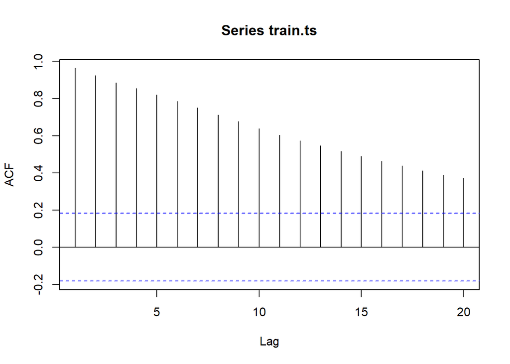

```r
acf(train.ts)
```

Berdasarkan plot ACF, terlihat bahwa plot ACF data menurun secara perlahan (*tails of slowly*). Hal ini juga menjadi indikasi bahwa data tidak stasioner dalam rataan

## Uji ADF

```r
tseries::adf.test(train.ts)
```

```
##
##  Augmented Dickey-Fuller Test
##
## data:  train.ts
## Dickey-Fuller = -2.4499, Lag order = 4, p-value = 0.3898
## alternative hypothesis: stationary
```

$H_0$ : Data tidak stasioner dalam rataan

$H_1$ : Data stasioner dalam rataan

Berdasarkan uji ADF tersebut, didapat *p-value* sebesar 0.3898 yang lebih besar dari taraf nyata 5% sehingga tak tolak $H_0$ dan menandakan bahwa data tidak stasioner dalam rataan. Hal ini sesuai dengan hasil eksplorasi menggunakan plot time series dan plot ACF, sehingga ketidakstasioneran model kedepannya harus ditangani

## Plot Box-Cox

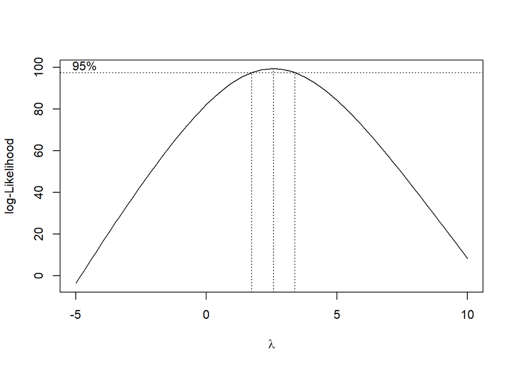

```r
index <- seq(1:115)
bc = boxcox(train.ts~index, lambda = seq(-5,10,by=1))
```

```r
#Nilai Rounded Lambda
lambda <- bc$x[which.max(bc$y)]
lambda
```

```
## [1] 2.575758
```

```r
#SK
bc$x[bc$y > max(bc$y) - 1/2 * qchisq(.95,1)]
```

```
##  [1] 1.818182 1.969697 2.121212 2.272727 2.424242 2.575758 2.727273 2.878788
##  [9] 3.030303 3.181818 3.333333
```

Plot Boxcox menunjukkan nilai *rounded value* ($\lambda$) optimum sebesar **2.575758** dan pada selang kepercayaan 95% nilai memiliki batas bawah **1.818182** dan batas atas **3.333333**. Selang tersebut tidak memuat nilai satu sehingga dapat dikatakan bahwa data tidak stasioner dalam ragam.

# Penanganan Ketidakstasioneran Data

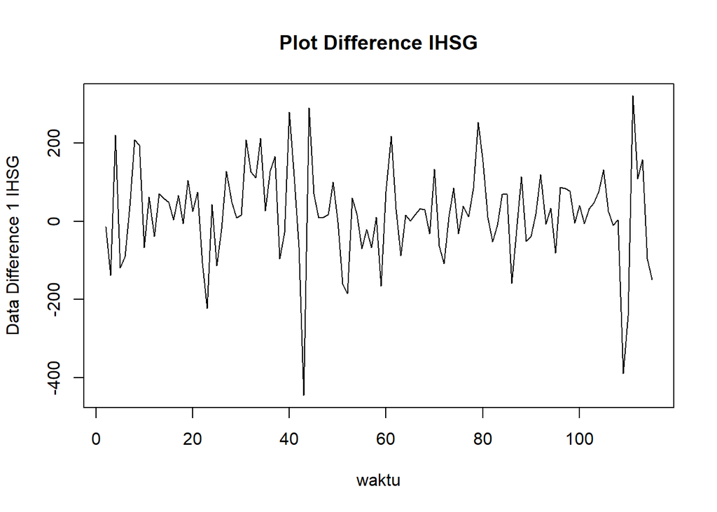

```r
train.diff<-diff(train.ts,differences = 1)
plot.ts(train.diff, lty=1, xlab="waktu", ylab="Data Difference 1 IHSG", main="Plot Difference IHSG")
```

Berdasarkan plot data deret waktu, terlihat bahwa data sudah stasioner dalam rataan ditandai dengan data bergerak pada nilai tengah tertentu (tidak terdapat trend ataupun musiman pada data)

## Plot ACF

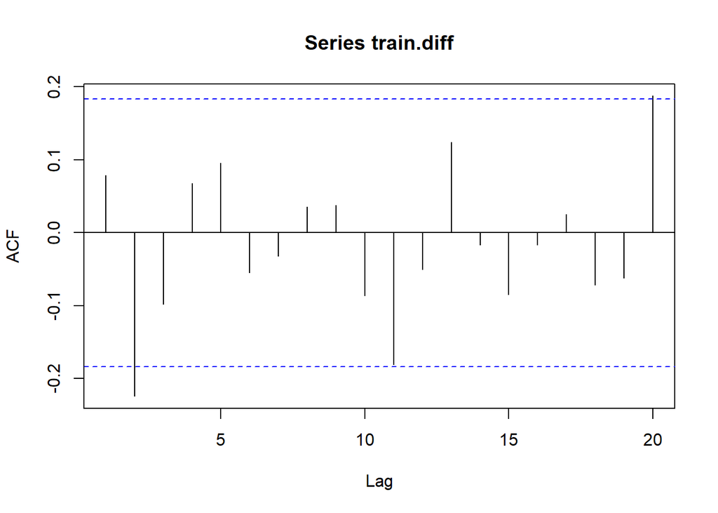

```r
acf(train.diff)
```

Berdasarkan plot tersebut, terlihat bahwa plot ACF cuts off pada lag ke 2. Hal ini menandakan data sudah stasioner dalam rataan dan ketidakstasioneran data telah berhasil tertangani.

## Uji ADF

```r
tseries::adf.test(train.diff)
```

```
##
##  Augmented Dickey-Fuller Test
##
## data:  train.diff
## Dickey-Fuller = -4.708, Lag order = 4, p-value = 0.01
## alternative hypothesis: stationary
```

$H_0$ : Data tidak stasioner dalam rataan

$H_1$ : Data stasioner dalam rataan

Berdasarkan uji ADF tersebut, didapat *p-value* sebesar 0.01 yang lebih kecil dari taraf nyata 5% sehingga tolak $H_0$ atau data stasioner dalam rataan. Hal ini sesuai dengan hasil eksplorasi menggunakan plot time series dan plot ACF, sehingga dalam hal ini ketidakstasioneran data sudah berhasil ditangani dan dapat dilanjutkan ke pemodelan

# Identifikasi Model

## Plot ACF

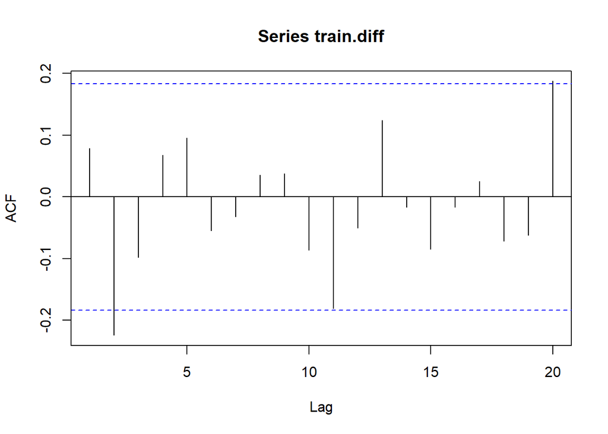

```r
acf(train.diff)
```

Berdasarkan plot tersebut, terlihat bahwa plot ACF cenderung *cuts off* pada lag ke 2, sehingga jika plot PACF dianggap *tails of*, maka model tentatifnya adalah ARIMA(0,1,2).

## Plot PACF

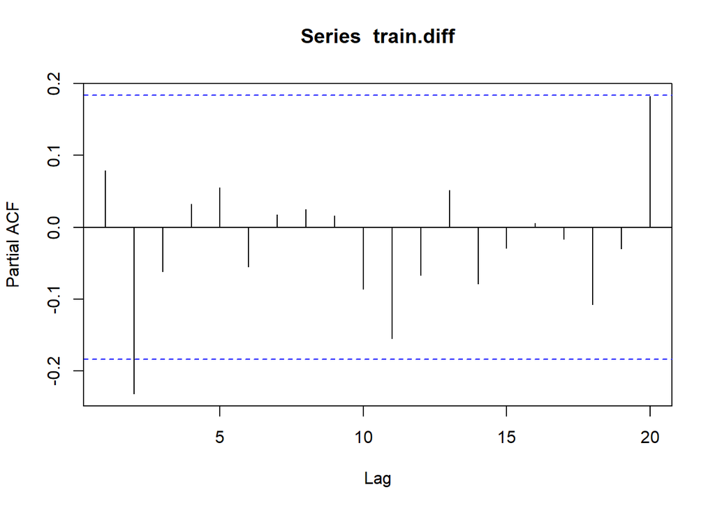

```r
pacf(train.diff)
```

Berdasarkan plot tersebut, terlihat bahwa plot PACF cenderung *cuts off* pada lag ke 2, sehingga jika plot ACF dianggap *tails of*, maka model tentatifnya adalah ARIMA(2,1,0).

Jika baik plot ACF maupun plot PACF keduanya dianggap tails of, maka model yang terbentuk adalah ARIMA(2,1,2)

#### Plot EACF

```r
eacf(train.diff)
```

```
## AR/MA
##   0 1 2 3 4 5 6 7 8 9 10 11 12 13
## 0 o x o o o o o o o o o  o  o  o
## 1 x x o o o o o o o o o  o  o  o
## 2 x o o o o o o o o o o  o  o  o
## 3 x o o o o o o o o o o  o  o  o
## 4 x x o o o o o o o o o  o  o  o
## 5 x x o o o o o o o o o  o  o  o
## 6 o x o o o o o o o o o  o  o  o
## 7 x o o o o o o o o o o  o  o  o
```

Identifikasi model menggunakan plot EACF dilakukan dengan melihat ujung segitiga pada pola segitiga nol. Dalam hal ini model tentatif yang terbentuk adalah ARIMA(1,1,2), ARIMA(2,1,1), ARIMA(3,1,1).

# Pendugaan Parameter Model Tentatif

## ARIMA(0,1,2)

```r
model1.da=Arima(train.diff, order=c(0,1,2),method="ML")
summary(model1.da) #AIC=1412.54
```

```
## Series: train.diff
## ARIMA(0,1,2)
##
## Coefficients:
##           ma1      ma2
##       -0.8527  -0.1473
## s.e.   0.1176   0.1147
##
## sigma^2 = 14582:  log likelihood = -703.27
## AIC=1412.54   AICc=1412.76   BIC=1420.73
##
## Training set error measures:
##                     ME    RMSE      MAE      MPE     MAPE      MASE        ACF1
## Training set -2.391877 119.158 84.56665 62.67515 177.2135 0.7197247 -0.03252704
```

```r
lmtest::coeftest(model1.da) #ma2 tidak signifikan
```

```
##
## z test of coefficients:
##
##     Estimate Std. Error z value  Pr(>|z|)
## ma1 -0.85267    0.11756 -7.2533 4.068e-13 ***
## ma2 -0.14733    0.11468 -1.2847    0.1989
## ---
## Signif. codes:  0 '***' 0.001 '**' 0.01 '*' 0.05 '.' 0.1 ' ' 1
```

## ARIMA(2,1,0)

```r
model2.da=Arima(train.diff, order=c(2,1,0),method="ML")
summary(model2.da) #AIC=1445.9
```

```
## Series: train.diff
## ARIMA(2,1,0)
##
## Coefficients:
##           ar1      ar2
##       -0.4662  -0.3915
## s.e.   0.0869   0.0890
##
## sigma^2 = 20301:  log likelihood = -719.95
## AIC=1445.9   AICc=1446.12   BIC=1454.08
##
## Training set error measures:
##                      ME     RMSE      MAE      MPE     MAPE      MASE
## Training set -0.8701929 140.5959 99.80282 87.25399 270.3644 0.8493958
##                    ACF1
## Training set -0.1349956
```

```r
lmtest::coeftest(model2.da) #seluruh parameter signifikan
```

```
##
## z test of coefficients:
##
##     Estimate Std. Error z value  Pr(>|z|)
## ar1 -0.46621    0.08693 -5.3630 8.184e-08 ***
## ar2 -0.39153    0.08904 -4.3972 1.097e-05 ***
## ---
## Signif. codes:  0 '***' 0.001 '**' 0.01 '*' 0.05 '.' 0.1 ' ' 1
```

## ARIMA(2,1,2)

```r
model3.da=Arima(train.diff, order=c(2,1,2),method="ML")
summary(model3.da) #AIC=1411.04
```

```
## Series: train.diff
## ARIMA(2,1,2)
##
## Coefficients:
##          ar1      ar2      ma1     ma2
##       0.2490  -0.2427  -1.1553  0.1554
## s.e.  0.3136   0.0931   0.3197  0.3180
##
## sigma^2 = 14060:  log likelihood = -700.52
## AIC=1411.04   AICc=1411.61   BIC=1424.68
##
## Training set error measures:
##                     ME     RMSE      MAE      MPE     MAPE      MASE
## Training set -4.060905 115.9471 81.82385 28.79724 205.3341 0.6963814
##                     ACF1
## Training set -0.01000473
```

```r
lmtest::coeftest(model3.da) #ar1 dan ma2 tidak signifikan
```

```
##
## z test of coefficients:
##
##      Estimate Std. Error z value  Pr(>|z|)
## ar1  0.248952   0.313602  0.7938 0.4272834
## ar2 -0.242722   0.093066 -2.6081 0.0091054 **
## ma1 -1.155277   0.319698 -3.6136 0.0003019 ***
## ma2  0.155377   0.318035  0.4886 0.6251583
## ---
## Signif. codes:  0 '***' 0.001 '**' 0.01 '*' 0.05 '.' 0.1 ' ' 1
```

## ARIMA(1,1,2)

```r
model4.da=Arima(train.diff, order=c(1,1,2),method="ML")
summary(model4.da) #AIC=11412.85
```

```
## Series: train.diff
## ARIMA(1,1,2)
##
## Coefficients:
##           ar1      ma1      ma2
##       -0.5139  -0.3399  -0.6601
## s.e.   0.3805   0.3367   0.3361
##
## sigma^2 = 14481:  log likelihood = -702.42
## AIC=1412.85   AICc=1413.22   BIC=1423.76
##
## Training set error measures:
##                     ME     RMSE      MAE      MPE     MAPE      MASE
## Training set -2.857175 118.2081 84.26853 50.49274 189.9772 0.7171875
##                     ACF1
## Training set -0.03986361
```

```r
lmtest::coeftest(model4.da) #ar1 dan ma1 tidak signifikan
```

```
##
## z test of coefficients:
##
##     Estimate Std. Error z value Pr(>|z|)
## ar1 -0.51389    0.38051 -1.3505  0.17684
## ma1 -0.33986    0.33672 -1.0093  0.31282
## ma2 -0.66008    0.33610 -1.9639  0.04954 *
## ---
## Signif. codes:  0 '***' 0.001 '**' 0.01 '*' 0.05 '.' 0.1 ' ' 1
```

# Analisis Sisaan

Model terbaik hasil identifikasi kemudian dicek asumsi sisaannya. Sisaan model ARIMA harus memenuhi asumsi normalitas, kebebasan sisaan, dan kehomogenan ragam. Diagnostik model dilakukan secara eksplorasi dan uji formal.

## Eksplorasi Sisaan

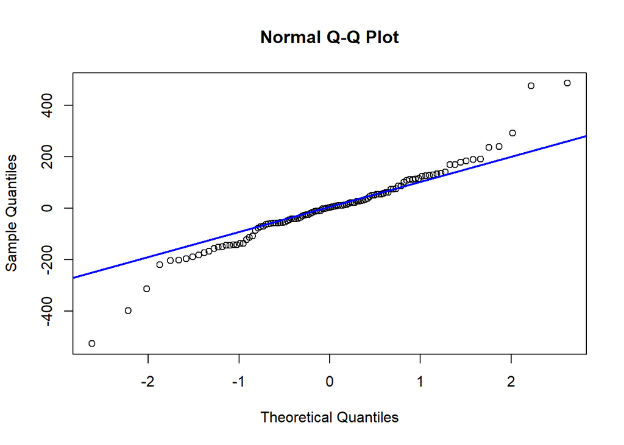

```r
#Eksplorasi
sisaan.da <- model2.da$residuals
par(mfrow=c(1,1))
qqnorm(sisaan.da)
qqline(sisaan.da, col = "blue", lwd = 2)
```

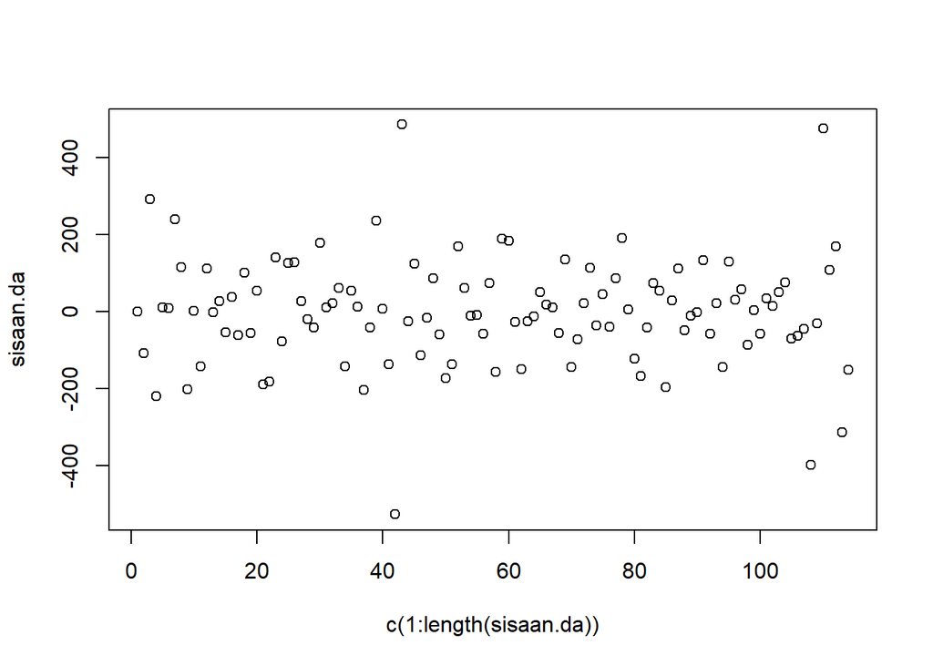

```r
plot(c(1:length(sisaan.da)),sisaan.da)
```

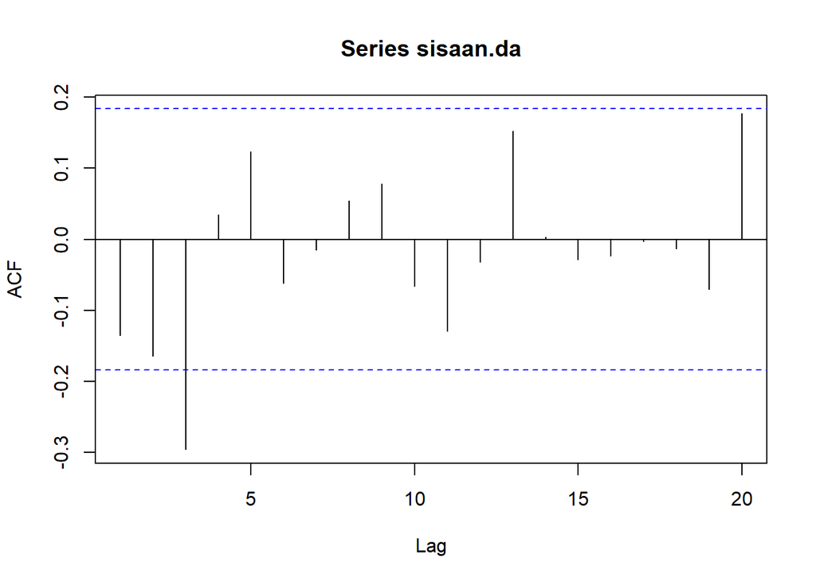

```r
acf(sisaan.da)
```

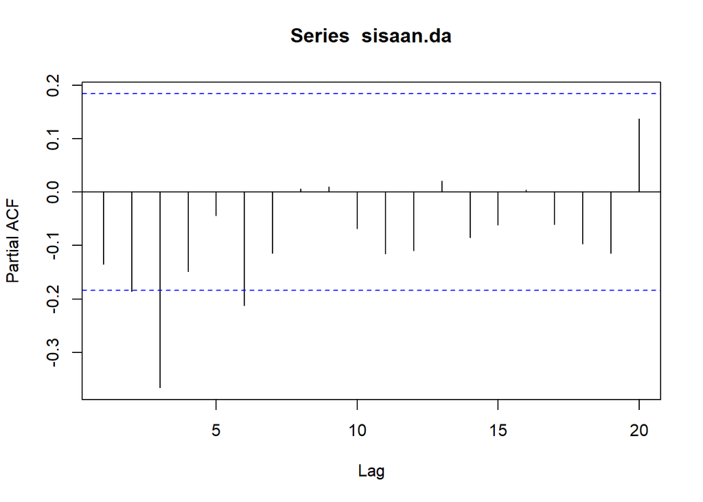

```r
pacf(sisaan.da)
```

```r
par(mfrow = c(1,1))
```

## Uji Formal

```r
#1) Sisaan Menyebar Normal
ks.test(sisaan.da,"pnorm")  #tak tolak H0 > sisaan menyebar normal
```

```
##
##  Asymptotic one-sample Kolmogorov-Smirnov test
##
## data:  sisaan.da
## D = 0.49995, p-value < 2.2e-16
## alternative hypothesis: two-sided
```

Selain dengan eksplorasi, asumsi tersebut dapat diuji menggunakan uji formal. Pada tahapan ini uji formal yang digunakan untuk normalitas adalah uji Kolmogorov-Smirnov (KS). Hipotesis pada uji KS adalah sebagai berikut.

$H_0$ : Sisaan menyebar normal

$H_1$ : Sisaan tidak menyebar normal

Berdasarkan uji KS tersebut, didapat *p-value* sebesar 2.2e-16 yang kurang dari taraf nyata 5% sehingga tolak $H_0$ dan menandakan bahwa sisaan tidak menyebar normal. Hal ini tidak sesuai dengan hasil eksplorasi menggunakan plot kuantil-kuantil normal.

```r
#2) Sisaan saling bebas/tidak ada autokorelasi
Box.test(sisaan.da, type = "Ljung")  #tak tolak H0 > sisaan saling bebas
```

```
##
##  Box-Ljung test
##
## data:  sisaan.da
## X-squared = 2.1327, df = 1, p-value = 0.1442
```

Selanjutnya akan dilakukan uji formal untuk kebebasan sisaan menggunakan uji Ljung-Box. Hipotesis yang digunakan adalah sebagai berikut.

$H_0$ : Sisaan saling bebas

$H_1$ : Sisaan tidak tidak saling bebas

Berdasarkan uji Ljung-Box tersebut, didapat *p-value* sebesar 0.1442 yang lebih besar dari taraf nyata 5% sehingga tak tolak $H_0$ dan menandakan bahwa sisaan saling bebas.

```r
#3) Sisaan homogen
Box.test((sisaan.da)^2, type = "Ljung")  #tak tolak H0 > sisaan homogen
```

```
##
##  Box-Ljung test
##
## data:  (sisaan.da)^2
## X-squared = 6.5746, df = 1, p-value = 0.01034
```

Hipotesis yang digunakan untuk uji kehomogenan ragam adalah sebagai berikut.

$H_0$ : Ragam sisaan homogen

$H_1$ : Ragam sisaan tidak homogen

Berdasarkan uji Ljung-Box terhadap sisaan kuadrat tersebut, didapat *p-value* sebesar 0.01034 yang lebih kecil dari taraf nyata 5% sehingga tolak $H_0$ dan menandakan bahwa ragam sisaan heterogen.

```r
#4) Nilai tengah sisaan sama dengan nol
t.test(sisaan.da, mu = 0, conf.level = 0.95)  #tak tolak h0 > nilai tengah sisaan sama dengan 0
```

```
##
##  One Sample t-test
##
## data:  sisaan.da
## t = -0.065795, df = 113, p-value = 0.9477
## alternative hypothesis: true mean is not equal to 0
## 95 percent confidence interval:
##  -27.07307  25.33269
## sample estimates:
##  mean of x
## -0.8701929
```

Terakhir, dengan uji-t, akan dicek apakah nilai tengah sisaan sama dengan nol. Hipotesis yang diujikan sebagai berikut.

$H_0$ : nilai tengah sisaan sama dengan 0

$H_1$ : nilai tengah sisaan tidak sama dengan 0

Berdasarkan uji-ttersebut, didapat *p-value* sebesar0.9477 yang lebih besar dari taraf nyata 5% sehingga tak tolak $H_0$ dan menandakan bahwa nilai tengah sisaan sama dengan nol.

# Overfitting

Tahapan selanjutnya adalah *overfitting* dilakukan dengan menaikkan orde AR(p) dan MA(q) dari model ARIMA(2,1,0) untuk melihat apakah terdapat model lain yang lebih baik dari model saat ini. Kandidat model *overfitting* adalah ARIMA(3,1,0) dan ARIMA(2,1,1).

## Model ARIMA(3,1,0)

```r
model.overfit1=Arima(train.diff, order=c(3,1,0),method="ML")
summary(model.overfit1) #1433.78
```

```
## Series: train.diff
## ARIMA(3,1,0)
##
## Coefficients:
##           ar1      ar2      ar3
##       -0.6019  -0.5479  -0.3553
## s.e.   0.0886   0.0925   0.0912
##
## sigma^2 = 18018:  log likelihood = -712.89
## AIC=1433.78   AICc=1434.15   BIC=1444.69
##
## Training set error measures:
##                      ME     RMSE      MAE       MPE     MAPE      MASE
## Training set -0.4254738 131.8556 95.83321 -5.821828 339.1933 0.8156115
##                     ACF1
## Training set -0.09548837
```

```r
lmtest::coeftest(model.overfit1) #semua parameter signifikan
```

```
##
## z test of coefficients:
##
##      Estimate Std. Error z value  Pr(>|z|)
## ar1 -0.601923   0.088641 -6.7906 1.117e-11 ***
## ar2 -0.547886   0.092543 -5.9203 3.213e-09 ***
## ar3 -0.355276   0.091209 -3.8952 9.813e-05 ***
## ---
## Signif. codes:  0 '***' 0.001 '**' 0.01 '*' 0.05 '.' 0.1 ' ' 1
```

## Model ARIMA(2,1,1)

```r
model.overfit2=Arima(train.diff, order=c(2,1,1),method="ML")
summary(model.overfit2) #1409.25
```

```
## Series: train.diff
## ARIMA(2,1,1)
##
## Coefficients:
##          ar1      ar2     ma1
##       0.1018  -0.2293  -1.000
## s.e.  0.0922   0.0927   0.031
##
## sigma^2 = 13968:  log likelihood = -700.63
## AIC=1409.25   AICc=1409.62   BIC=1420.16
##
## Training set error measures:
##                    ME     RMSE      MAE      MPE     MAPE      MASE        ACF1
## Training set -3.94285 116.0933 81.96369 27.03611 210.6193 0.6975716 -0.01975933
```

```r
lmtest::coeftest(model.overfit2) #ar1 tidak signifikan
```

```
##
## z test of coefficients:
##
##      Estimate Std. Error  z value Pr(>|z|)
## ar1  0.101834   0.092195   1.1045  0.26936
## ar2 -0.229287   0.092734  -2.4725  0.01342 *
## ma1 -0.999994   0.030988 -32.2699  < 2e-16 ***
## ---
## Signif. codes:  0 '***' 0.001 '**' 0.01 '*' 0.05 '.' 0.1 ' ' 1
```

model yang dipilih adalah model awal, yaitu ARIMA(3,1,0) karena memiliki AIC lebih kecil dari ARIMA(2,1,0) dan semua parameter signifikan.

Oleh karena itu, dilakukan lagi Analisis sisaan untuk ARIMA(3,1,0)

# Analisis Sisaan

Model terbaik hasil identifikasi kemudian dicek asumsi sisaannya. Sisaan model ARIMA harus memenuhi asumsi normalitas, kebebasan sisaan, dan kehomogenan ragam. Diagnostik model dilakukan secara eksplorasi dan uji formal.

## Eksplorasi Sisaan

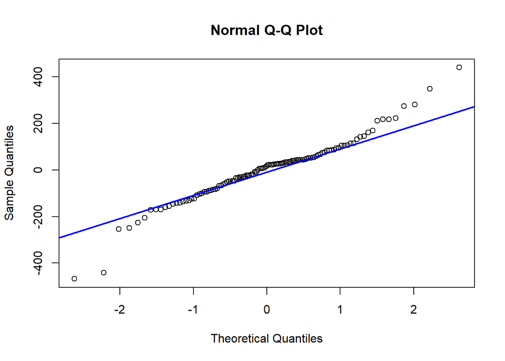

```r
#Eksplorasi
sisaan.da1 <- model.overfit1$residuals
par(mfrow=c(1,1))
qqnorm(sisaan.da1)
qqline(sisaan.da1, col = "blue", lwd = 2)
```

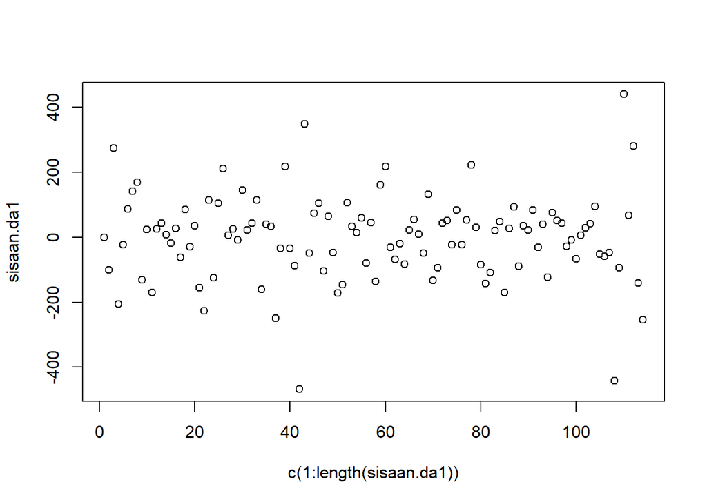

```r
plot(c(1:length(sisaan.da1)),sisaan.da1)
```

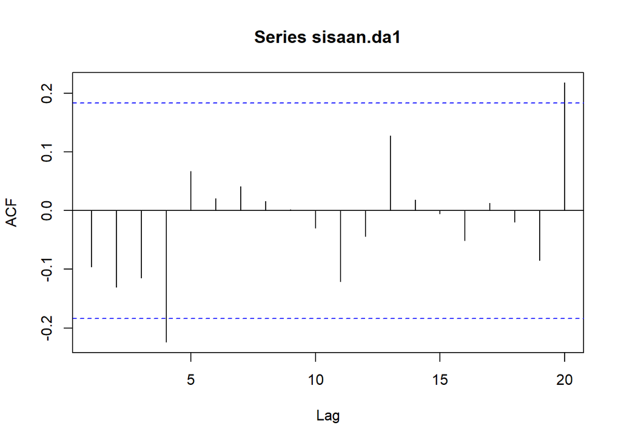

```r
acf(sisaan.da1)
```

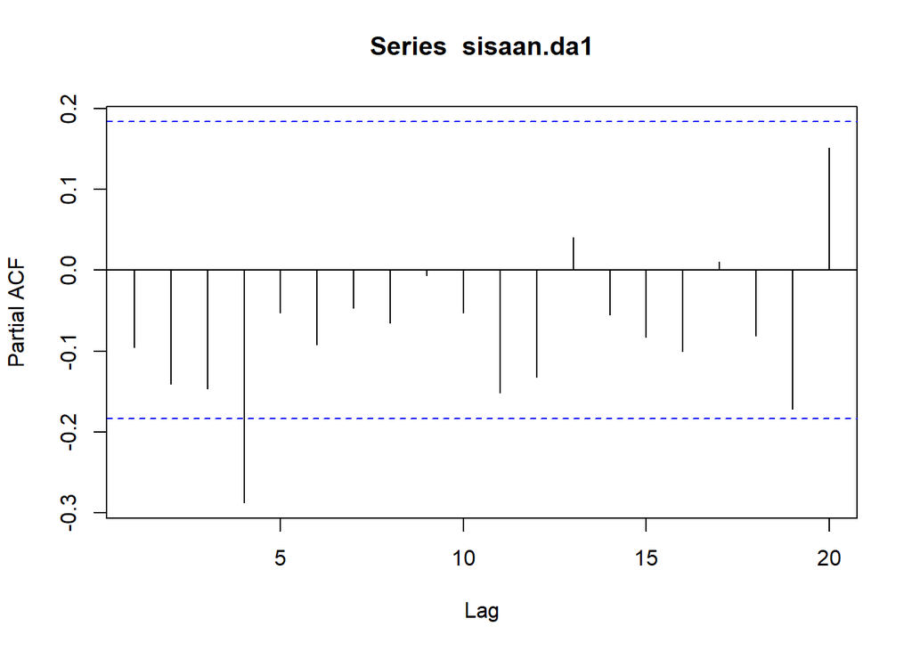

```r
pacf(sisaan.da1)
```

```r
par(mfrow = c(1,1))
```

Berdasarkan plot kuantil-kuantil normal, secara eksplorasi ditunjukkan sisaan menyebar normal mengikuti garis $45^{\circ}$. Kemudian dapat dilihat juga lebar pita sisaan yang cenderung sama menandakan bahwa sisaan memiliki ragam yang homogen. Akan tetapi, plot ACF dan PACF sisaan ARIMA(3,1,0) signifikan pada lag ke-4 sehingga sisaan tidak saling bebas. Kondisi ini akan diuji lebih lanjut dengan uji formal.

## Uji Formal

```r
#1) Sisaan Menyebar Normal
ks.test(sisaan.da1,"pnorm")  #tak tolak H0 > sisaan menyebar normal
```

```
##
##  Asymptotic one-sample Kolmogorov-Smirnov test
##
## data:  sisaan.da1
## D = 0.54386, p-value < 2.2e-16
## alternative hypothesis: two-sided
```

Selain dengan eksplorasi, asumsi tersebut dapat diuji menggunakan uji formal. Pada tahapan ini uji formal yang digunakan untuk normalitas adalah uji Kolmogorov-Smirnov (KS). Hipotesis pada uji KS adalah sebagai berikut.

$H_0$ : Sisaan menyebar normal

$H_1$ : Sisaan tidak menyebar normal

```r
#2) Sisaan saling bebas/tidak ada autokorelasi
Box.test(sisaan.da1, type = "Ljung")
```

```
##
##  Box-Ljung test
##
## data:  sisaan.da1
## X-squared = 1.0671, df = 1, p-value = 0.3016
```

```r
#tak tolak H0 > sisaan saling bebas
```

Selanjutnya akan dilakukan uji formal untuk kebebasan sisaan menggunakan uji Ljung-Box. Hipotesis yang digunakan adalah sebagai berikut.

$H_0$ : Sisaan saling bebas

$H_1$ : Sisaan tidak tidak saling bebas

Berdasarkan uji Ljung-Box tersebut, didapat *p-value* sebesar 0.3016 yang lebih besar dari taraf nyata 5% sehingga tak tolak $H_0$ dan menandakan bahwa sisaan saling bebas.

```r
#3) Sisaan homogen
Box.test((sisaan.da1)^2, type = "Ljung")
```

```
##
##  Box-Ljung test
##
## data:  (sisaan.da1)^2
## X-squared = 1.3964, df = 1, p-value = 0.2373
```

```r
#tak tolak H0 > sisaan homogen
```

Hipotesis yang digunakan untuk uji kehomogenan ragam adalah sebagai berikut.

$H_0$ : Ragam sisaan homogen

$H_1$ : Ragam sisaan tidak homogen

Berdasarkan uji Ljung-Box terhadap sisaan kuadrat tersebut, didapat *p-value* sebesar 0.2373yang lebih besar dari taraf nyata 5% sehingga tak tolak $H_0$ dan menandakan bahwa ragam sisaan homogen.

```r
#4) Nilai tengah sisaan sama dengan nol
t.test(sisaan.da1, mu = 0, conf.level = 0.95)
```

```
##
##  One Sample t-test
##
## data:  sisaan.da1
## t = -0.034302, df = 113, p-value = 0.9727
## alternative hypothesis: true mean is not equal to 0
## 95 percent confidence interval:
##  -24.99976  24.14881
## sample estimates:
##  mean of x
## -0.4254738
```

```r
#tak tolak h0 > nilai tengah sisaan sama dengan 0
```

Terakhir, dengan uji-t, akan dicek apakah nilai tengah sisaan sama dengan nol. Hipotesis yang diujikan sebagai berikut.

$H_0$ : nilai tengah sisaan sama dengan 0

$H_1$ : nilai tengah sisaan tidak sama dengan 0

Berdasarkan uji-ttersebut, didapat *p-value* sebesar 0.9727yang lebih besar dari taraf nyata 5% sehingga tak tolak $H_0$ dan menandakan bahwa nilai tengah sisaan sama dengan nol.

# Peramalan

Peramalan dilakukan menggunakan fungsi `forecast()` . Contoh peramalan berikut ini dilakukan untuk 31 hari ke depan.

```r
#---FORECAST---#
ramalan.da <- forecast::forecast(model.overfit1, h = 31)
ramalan.da
```

```
##     Point Forecast     Lo 80    Hi 80     Lo 95    Hi 95
## 116       3.803331 -168.2213 175.8279 -259.2856 266.8923
## 117      30.548263 -154.6053 215.7018 -252.6197 313.7162
## 118     -50.681654 -239.4094 138.0461 -339.3158 237.9525
## 119     -70.969946 -266.5682 124.6283 -370.1117 228.1718
## 120     -23.755076 -241.9676 194.4575 -357.4823 309.9722
## 121     -12.200128 -242.1904 217.7901 -363.9399 339.5396
## 122     -37.815728 -274.7724 199.1410 -400.2097 324.5782
## 123     -45.502187 -290.8247 199.8203 -420.6906 329.6862
## 124     -30.946303 -287.9883 226.0957 -424.0582 362.1656
## 125     -26.395928 -293.0037 240.2118 -434.1373 381.3454
## 126     -34.379052 -308.7529 239.9948 -453.9977 385.2396
## 127     -37.238260 -319.6676 245.1911 -469.1767 394.7002
## 128     -32.760036 -323.9905 258.4704 -478.1585 412.6384
## 129     -31.052854 -330.4691 268.3634 -488.9704 426.8647
```

[output cut: 17 more lines]

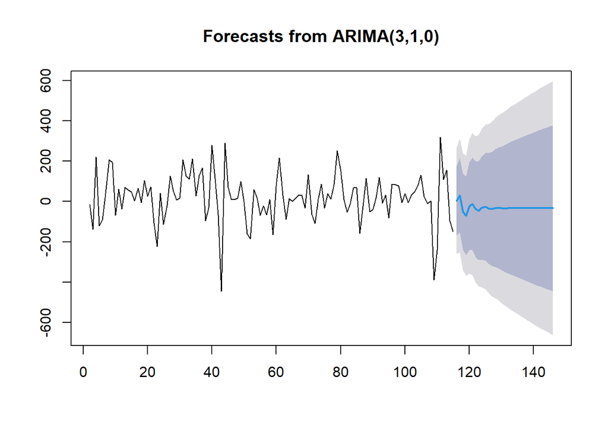

```r
data.ramalan.da <- ramalan.da$mean
plot(ramalan.da)
```

Berdasarkan hasil plot ramalan di atas, dapat dilihat bahwa ramalan ARIMA(3,1,0) cenderung stabil hingga akhir periode. Selanjutnya, dapat dicari nilai akurasi antara hasil ramalan dengan data uji sebagai berikut.

```r
pt_1 <- train.ts[115] #nilai akhir data latih
hasil.forc.Diff <- data.ramalan.da
hasil <- diffinv(hasil.forc.Diff, differences = 1) + pt_1
hasil
```

```
## Time Series:
## Start = 115
## End = 146
## Frequency = 1
##  [1] 6936.967 6940.770 6971.318 6920.637 6849.667 6825.912 6813.712 6775.896
##  [9] 6730.394 6699.447 6673.051 6638.672 6601.434 6568.674 6537.621 6504.103
## [17] 6469.542 6436.354 6403.786 6370.463 6336.767 6303.489 6270.432 6237.146
## [25] 6203.728 6170.436 6137.222 6103.939 6070.610 6037.318 6004.054 5970.769
```

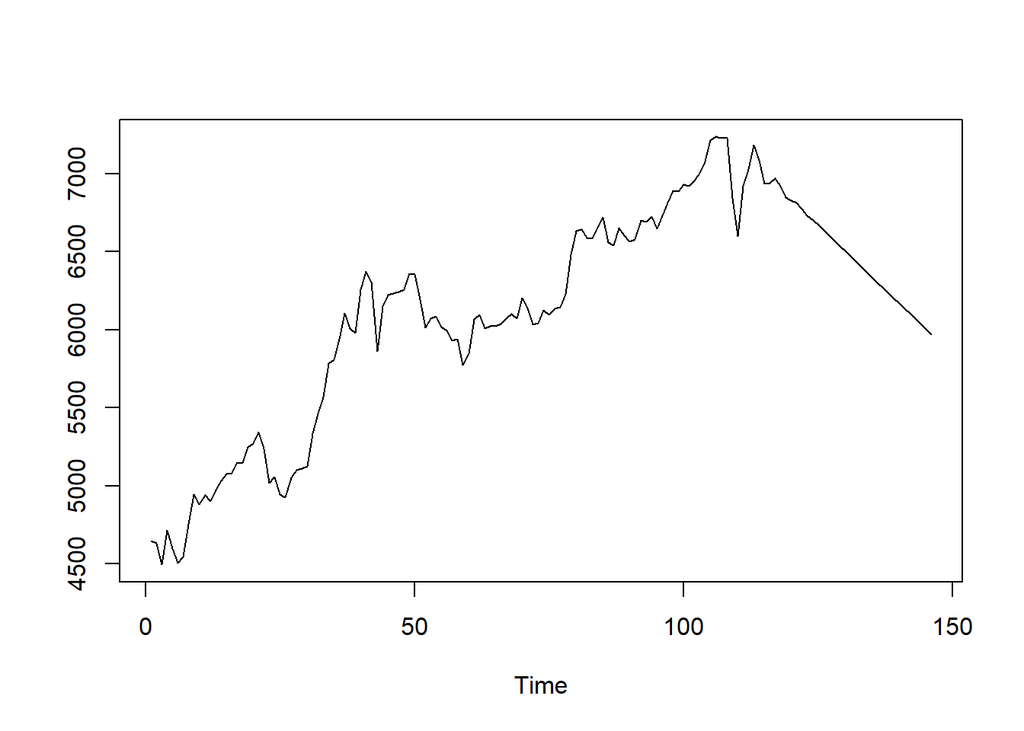

```r
#has.1 sama hasilnya dengan: cumsum(c(pt_1,hasil.forc.Diff))
ts.plot(train.ts,hasil)
```

```r
perbandingan.da<-matrix(data=c(head(test.ts, n=28), hasil[-1]),
                     nrow = 28, ncol = 2)
colnames(perbandingan.da)<-c("Aktual","Hasil Forecast")
perbandingan.da
```

```
##         Aktual Hasil Forecast
##  [1,] 7042.937       6940.770
##  [2,] 6794.328       6971.318
##  [3,] 6740.219       6920.637
##  [4,] 6651.905       6849.667
##  [5,] 6886.962       6825.912
##  [6,] 6951.123       6813.712
##  [7,] 7084.655       6775.896
##  [8,] 7129.277       6730.394
##  [9,] 7172.434       6699.447
## [10,] 7135.248       6673.051
## [11,] 7177.179       6638.672
## [12,] 7242.656       6601.434
## [13,] 7168.870       6568.674
## [14,] 7178.583       6537.621
## [15,] 7040.798       6504.103
## [16,] 7026.783       6469.542
## [17,] 6814.530       6436.354
## [18,] 7017.771       6403.786
## [19,] 7056.040       6370.463
## [20,] 7045.527       6336.767
## [21,] 7089.206       6303.489
## [22,] 7082.181       6270.432
## [23,] 7053.150       6237.146
## [24,] 7019.639       6203.728
## [25,] 6715.118       6170.436
## [26,] 6812.193       6137.222
## [27,] 6800.673       6103.939
## [28,] 6835.808       6070.610
```

```r
accuracy(ts(hasil[-1]), head(test.ts, n=28))
```

```
##               ME     RMSE     MAE      MPE     MAPE      ACF1 Theil's U
## Test set 471.449 561.3136 511.104 6.698776 7.288398 0.8761914  4.752978
```

Dari hasil diperoleh nilai MAPE 7.288398 sangat baik untuk menggambarkan model deret waktu